# hw7

Renjie Liu

5/14/2021

### Question 1:

Load the data and calculate the average cost of a night’s accommodation in Victoria each month (i.e., Cost variable). a) Plot the CPI and Cost time series. b) Plot the Cost time series against the CPI time series and calculate the correlation between CPI and Cost. Discuss your results and explain why the logarithms of both variables need to be taken before fitting any models. c) Plot the 𝑙𝑜𝑔(𝐶𝑃𝐼) and 𝑙𝑜𝑔(𝐶𝑜𝑠𝑡) time series and calculate the correlation between the logarithms of both CPI and Cost.

```r
library(ggplot2)
library(fpp)
library(TSA)
library(forecast)
```

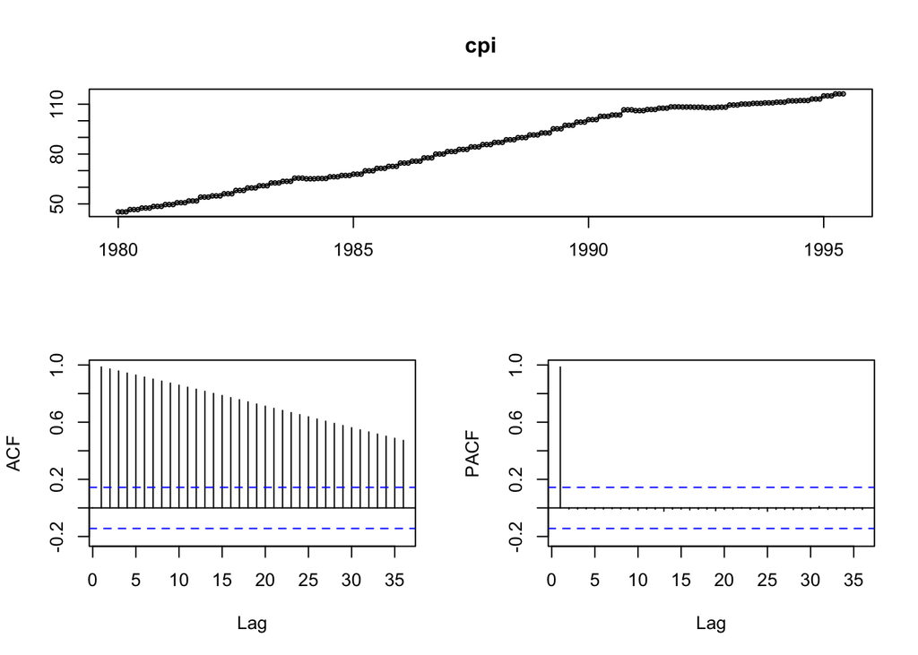

```r
load('motel.rda')
cost <- motel[,'Takings']*1000 / motel[,'Roomnights']
cpi <- motel[,'CPI']

data <- cbind(CPI = motel[,'CPI'] , Cost = motel[,'Takings']*1000 / motel[,'Roomnights'])

tsdisplay(cpi)
```

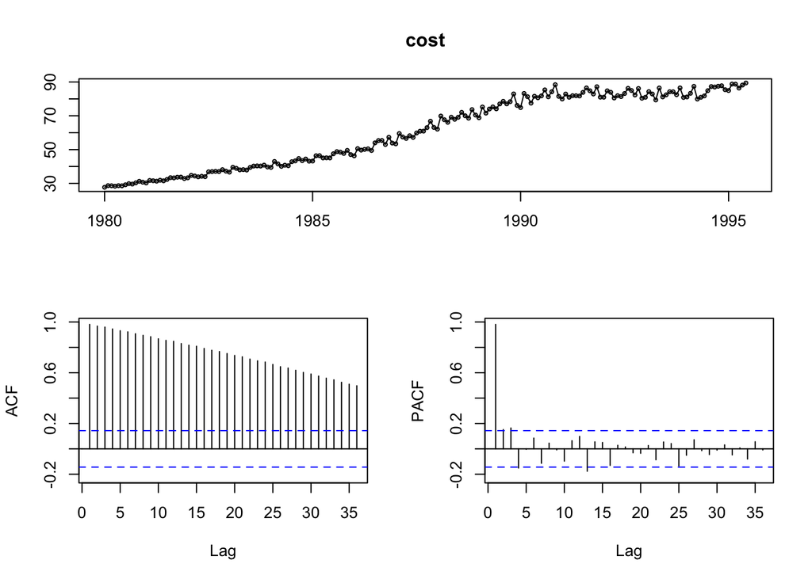

```r
tsdisplay(cost)
```

Both cost and CPI have positive trend, and cost has possible seasonality. The variance for cost also appears to be increasing.

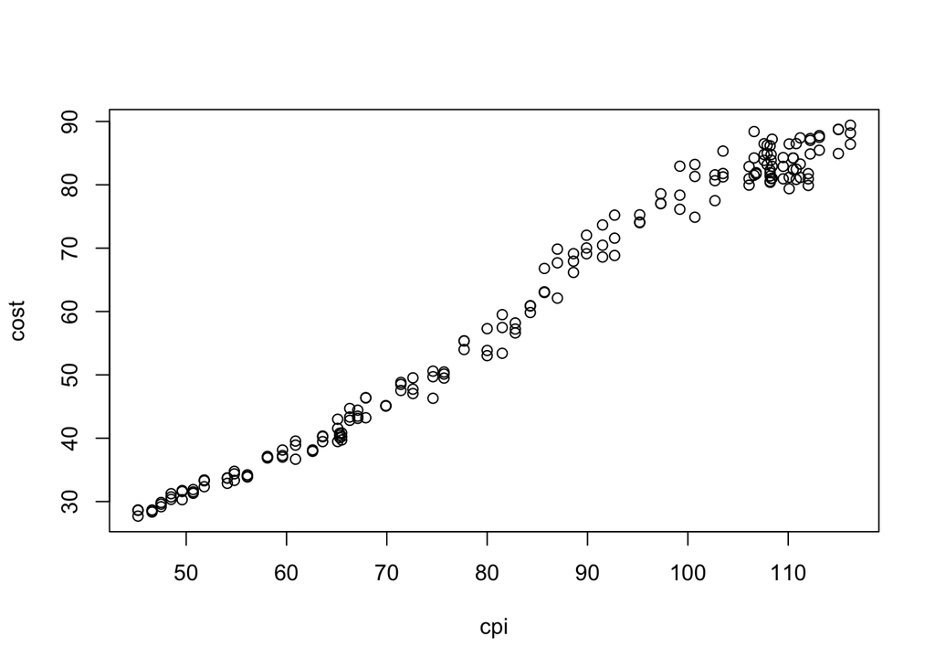

```r
plot(x = cpi, y = cost)
```

```r
cor(cpi,cost)
```

```
## [1] 0.9907186
```

From the plot we can see a very storng correlation. And from the correlation function, we see a very strong correlation 0.991, very close to 1.

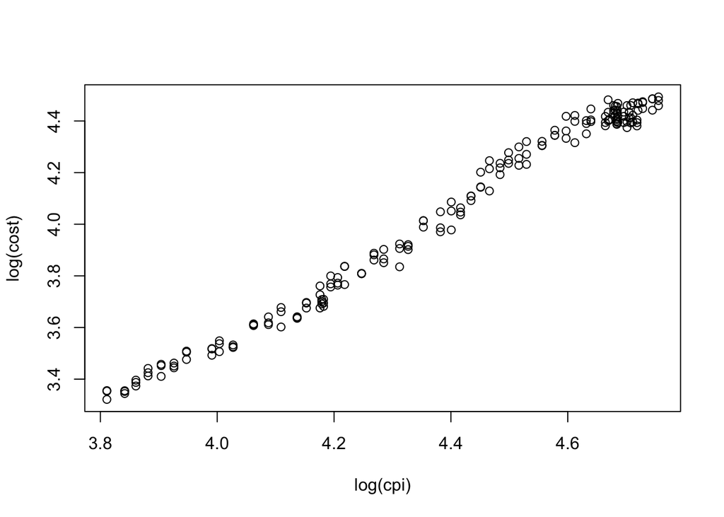

```r
plot(x = log(cpi), y = log(cost))
```

```r
cor(log(cpi),log(cost))
```

```
## [1] 0.9929902
```

The plot of the log cpi and cost also shows a positive correlation. From the function we can see that there are still very strong correlation, 0.993 very close to 1. The log transformation for cpi and cost are needed because they are not in the same scale, and we need to make the variance for cost stay constant.

### Question 2:

Question 2: a) Use the linear model with time series components function tslm() to fit a linear model to the 𝑙𝑜𝑔(𝐶𝑜𝑠𝑡) time series as a function of the 𝑙𝑜𝑔(𝐶𝑃𝐼) time series (i.e., CPI ➔ Independent variable, Cost➔ Dependent variable).

```r
lm1 <- tslm(log(cost)~log(cpi))
lm1
```

```
##
## Call:
## tslm(formula = log(cost) ~ log(cpi))
##
## Coefficients:
## (Intercept)     log(cpi)
##      -1.682        1.303
```

2. Plot 𝑙𝑜𝑔(𝐶𝑃𝐼) against 𝑙𝑜𝑔(𝐶𝑜𝑠𝑡) and the fitted trend.

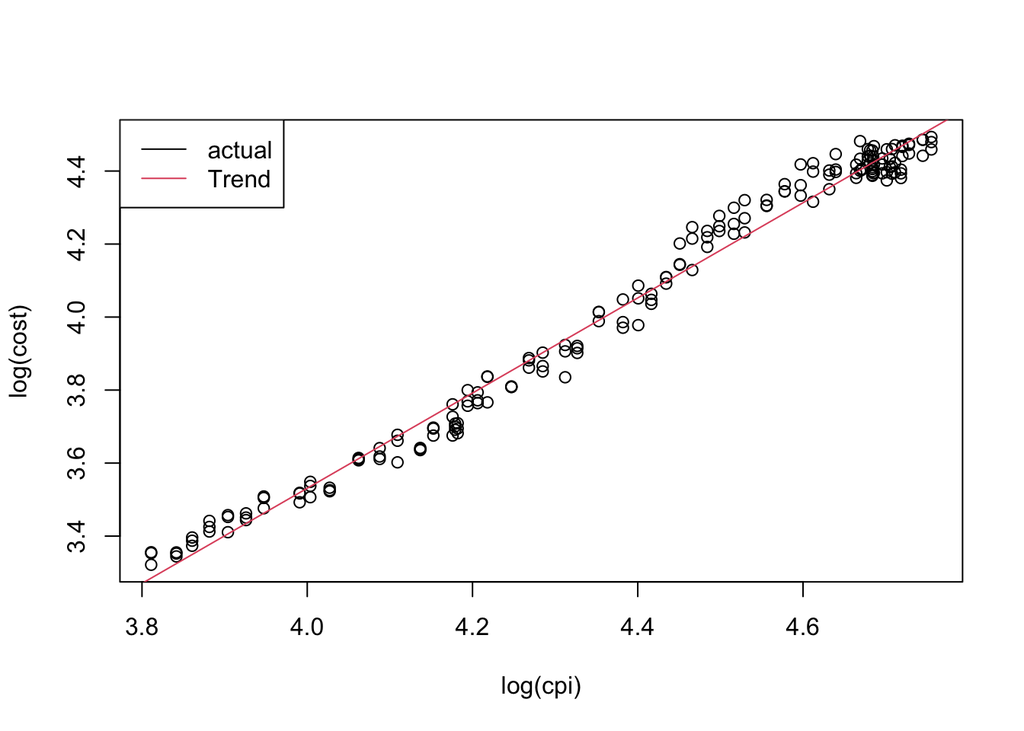

```r
plot(x = log(cpi), y = log(cost), col = 1)
abline(lm1, col = 2)
legend('topleft', legend = c('actual' , 'Trend'), col = 1:2, lty = 1)
```

3. Use the summary() function to summarize the generated model , and the checkresiduals() function to evaluate the residuals. Discuss your results.

```r
summary(lm1)
```

```
##
## Call:
## tslm(formula = log(cost) ~ log(cpi))
##
## Residuals:
##       Min        1Q    Median        3Q       Max
## -0.102841 -0.033939 -0.002071  0.030363  0.108670
##
## Coefficients:
##             Estimate Std. Error t value Pr(>|t|)
## (Intercept) -1.68246    0.05032  -33.44   <2e-16 ***
## log(cpi)     1.30339    0.01144  113.96   <2e-16 ***
## ---
## Signif. codes:  0 '***' 0.001 '**' 0.01 '*' 0.05 '.' 0.1 ' ' 1
##
## Residual standard error: 0.04487 on 184 degrees of freedom
## Multiple R-squared:  0.986,  Adjusted R-squared:  0.986
## F-statistic: 1.299e+04 on 1 and 184 DF,  p-value: < 2.2e-16
```

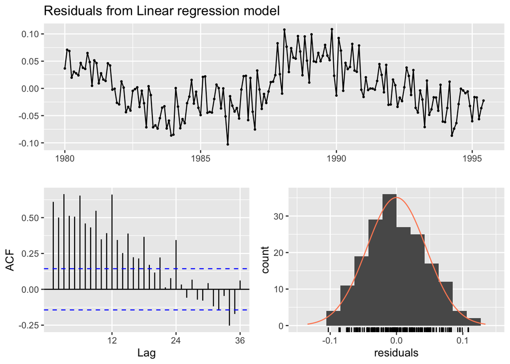

```
##
##  Breusch-Godfrey test for serial correlation of order up to 24
##
## data:  Residuals from Linear regression model
## LM test = 148.84, df = 24, p-value < 2.2e-16
```

```r
checkresiduals(lm1)
```

The linear model has two variable, the intercept and the log(cpi) Both of theses two variables are significant because their p values is less than 0.05. The adjusted r-squared is 0.986, very close to 1 means that this model capture the linaer relationship in the data very well.

The residuals from the tslm model does not look like white noise. There are many lags that are significant in the acf plot of the residuals. The p value is also smaller than 0.05 which rejects the null hypothesis that the residuals is a white noise. This means that the tslm model does not capture the trend very well for the dataset.

### Question 3:

Use the auto.arima() function to fit an appropriate regression model with ARIMA errors to the Cost and CPI time series(i.e., CPI ➔ Independent variable, Cost➔ Dependent variable). Set the Order of seasonaldifferencing argument, D, to 1 and the ‘lambda’ argument to 0 to reflect a logarithmic transformation. a) Use the summary() function to summarize the generated model.

```r
auto1 <- auto.arima(D = 1,lambda = 0, y = cost, xreg = cpi)
summary(auto1)
```

```
## Series: cost
## Regression with ARIMA(0,1,1)(0,1,2)[12] errors
## Box Cox transformation: lambda= 0
##
## Coefficients:
##           ma1     sma1    sma2    xreg
##       -0.5516  -0.6160  0.1374  0.0099
## s.e.   0.0602   0.0785  0.1009  0.0025
##
## sigma^2 estimated as 0.0003728:  log likelihood=437.07
## AIC=-864.14   AICc=-863.79   BIC=-848.38
##
## Training set error measures:
##                       ME     RMSE       MAE        MPE     MAPE      MASE
## Training set -0.08012207 1.307136 0.8968091 -0.1126491 1.349787 0.2115032
##                     ACF1
## Training set -0.06269298
```

2. Use the checkresiduals() function to evaluate the residuals. Discuss your results.

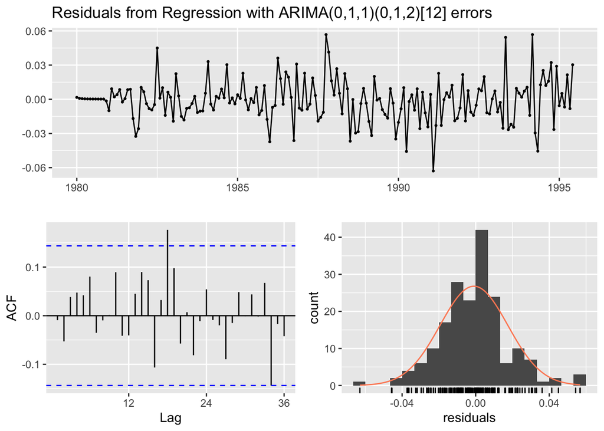

```
##
##  Ljung-Box test
##
## data:  Residuals from Regression with ARIMA(0,1,1)(0,1,2)[12] errors
## Q* = 22.342, df = 20, p-value = 0.3223
##
## Model df: 4.   Total lags used: 24
```

```r
checkresiduals(auto1)
```

### Question 4:

1. Calculate and plot a naïve forecast of CPI for the next 18 months.

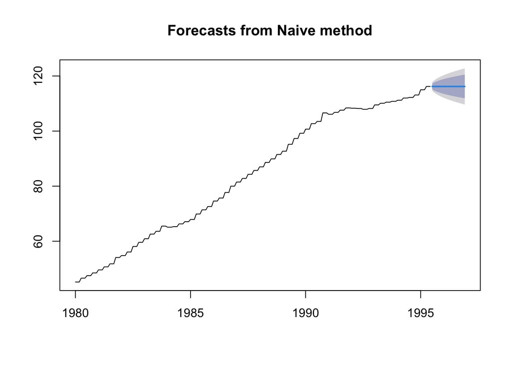

```r
naive_cpi <- naive(cpi, h=18, level=c(80,95))
plot(naive_cpi)
```

2. Forecast and plot the average1 price per room (i.e., Cost) for the next 18 months using the fitted model from Question 3 and the naïve forecast of CPI. Discuss your results.

```r
f1 <- forecast(auto1, h = 18, xreg = naive_cpi$mean)
f1
```

```
##          Point Forecast    Lo 80    Hi 80    Lo 95     Hi 95
## Jul 1995       89.97440 87.77538 92.22852 86.63312  93.44455
## Aug 1995       92.49848 90.02378 95.04121 88.74067  96.41543
## Sep 1995       91.97103 89.31530 94.70572 87.94063  96.18614
## Oct 1995       90.33995 87.55335 93.21525 86.11317  94.77421
## Nov 1995       93.11977 90.07549 96.26695 88.50444  97.97579
## Dec 1995       88.33935 85.29739 91.48980 83.72971  93.20277
## Jan 1996       87.39830 84.24415 90.67054 82.62078  92.45207
## Feb 1996       90.64320 87.22891 94.19113 85.47386  96.12517
## Mar 1996       91.94087 88.33878 95.68983 86.48943  97.73591
## Apr 1996       86.40297 82.89243 90.06217 81.09217  92.06156
## May 1996       88.90656 85.16998 92.80707 83.25595  94.94068
## Jun 1996       88.69944 84.85178 92.72157 82.88299  94.92407
## Jul 1996       90.40999 86.09547 94.94072 83.89549  97.43035
## Aug 1996       92.92288 88.28029 97.80961 85.91730 100.49968
## Sep 1996       92.50991 87.69031 97.59441 85.24145 100.39814
## Oct 1996       91.16304 86.22711 96.38151 83.72331  99.26387
## Nov 1996       93.39758 88.15714 98.94954 85.50311 102.02095
## Dec 1996       89.13543 83.96542 94.62378 81.35109  97.66464
```

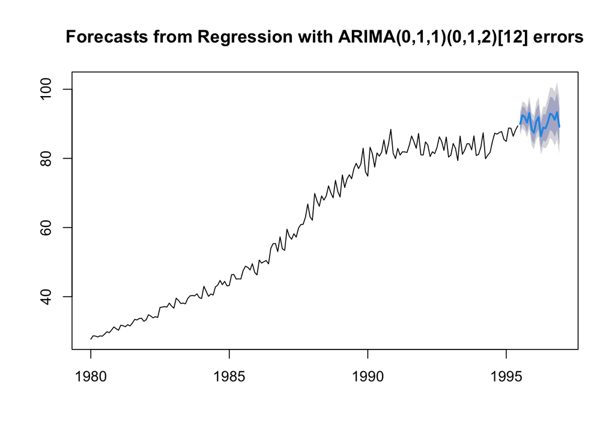

```r
plot(f1)
```

### Question 5:

1. Use the VAR() function to fit a VAR(10) model to the 𝑙𝑜𝑔(𝐶𝑜𝑠𝑡) and 𝑙𝑜𝑔(𝐶𝑃𝐼) time series. Set the ‘type’ and ‘season’ arguments to ‘both’ and 12, respectively.

```r
library(vars)
x <- cbind(log(cost),log(cpi))
var1 <- VAR(x,p=10, type='both', season = 12)
var1
```

```
##
## VAR Estimation Results:
## =======================
##
## Estimated coefficients for equation log.cost.:
## ==============================================
## Call:
## log.cost. = log.cost..l1 + log.cpi..l1 + log.cost..l2 + log.cpi..l2 + log.cost..l3 + log.cpi..l3 + log.cost..l4 + log.cpi..l4 + log.cost..l5 + log.cpi..l5 + log.cost..l6 + log.cpi..l6 + log.cost..l7 + log.cpi..l7 + log.cost..l8 + log.cpi..l8 + log.cost..l9 + log.cpi..l9 + log.cost..l10 + log.cpi.…
##
##  log.cost..l1   log.cpi..l1  log.cost..l2   log.cpi..l2  log.cost..l3
##  3.917580e-01  3.233608e-02  2.360905e-01  5.202958e-01  2.619293e-01
##   log.cpi..l3  log.cost..l4   log.cpi..l4  log.cost..l5   log.cpi..l5
## -3.801122e-01  6.684129e-02  2.112786e-01  1.063846e-01 -7.446007e-01
##  log.cost..l6   log.cpi..l6  log.cost..l7   log.cpi..l7  log.cost..l8
##  1.080034e-01  5.487893e-01 -4.795450e-02 -1.154290e-02 -1.478150e-01
##   log.cpi..l8  log.cost..l9   log.cpi..l9 log.cost..l10  log.cpi..l10
## -5.394842e-02 -2.312520e-02  2.196188e-01 -5.533626e-03 -2.696121e-01
##         const         trend           sd1           sd2           sd3
## -9.512177e-02 -3.844281e-05 -5.828898e-03  6.573251e-02  5.285851e-02
##           sd4           sd5           sd6           sd7           sd8
##  1.640604e-02  3.547097e-02  3.034750e-02  6.703892e-02  6.439936e-02
##           sd9          sd10          sd11
##  4.905043e-02  3.428828e-02  6.615394e-02
##
##
## Estimated coefficients for equation log.cpi.:
## =============================================
## Call:
## log.cpi. = log.cost..l1 + log.cpi..l1 + log.cost..l2 + log.cpi..l2 + log.cost..l3 + log.cpi..l3 + log.cost..l4 + log.cpi..l4 + log.cost..l5 + log.cpi..l5 + log.cost..l6 + log.cpi..l6 + log.cost..l7 + log.cpi..l7 + log.cost..l8 + log.cpi..l8 + log.cost..l9 + log.cpi..l9 + log.cost..l10 + log.cpi..…
##
##  log.cost..l1   log.cpi..l1  log.cost..l2   log.cpi..l2  log.cost..l3
##  7.698762e-03  9.056939e-01  1.331794e-02  2.105522e-02  1.907511e-02
##   log.cpi..l3  log.cost..l4   log.cpi..l4  log.cost..l5   log.cpi..l5
##  1.484361e-01  2.843072e-02 -1.709409e-01 -9.068143e-03  1.596020e-02
##  log.cost..l6   log.cpi..l6  log.cost..l7   log.cpi..l7  log.cost..l8
##  1.551147e-02  2.131662e-01 -6.792436e-03 -2.080322e-01 -4.947187e-02
##   log.cpi..l8  log.cost..l9   log.cpi..l9 log.cost..l10  log.cpi..l10
##  1.165448e-02 -2.473845e-02  3.911678e-01  2.798236e-02 -3.762730e-01
##         const         trend           sd1           sd2           sd3
##  1.160321e-01  8.753197e-05 -5.691893e-05  2.114526e-03  1.972777e-03
##           sd4           sd5           sd6           sd7           sd8
##  9.136474e-03  4.215878e-03  1.760137e-03  7.301299e-03  3.663619e-03
##           sd9          sd10          sd11
## -5.518211e-04  1.234958e-02  4.397260e-03
```

2. Forecast and plot the average price per room (i.e., Cost) and CPI for the next 18 months using your fitted model.

```r
var_pred <- forecast(var1,h=18)
var_pred
```

```
## log.cost.
##          Point Forecast    Lo 80    Hi 80    Lo 95    Hi 95
## Jul 1995       4.514645 4.489981 4.539308 4.476925 4.552365
## Aug 1995       4.536276 4.509773 4.562779 4.495744 4.576809
## Sep 1995       4.533696 4.505100 4.562293 4.489962 4.577431
## Oct 1995       4.528037 4.496555 4.559518 4.479890 4.576183
## Nov 1995       4.566296 4.532298 4.600294 4.514300 4.618291
## Dec 1995       4.522756 4.485991 4.559522 4.466529 4.578984
## Jan 1996       4.509267 4.468613 4.549920 4.447092 4.571441
## Feb 1996       4.575961 4.532186 4.619737 4.509013 4.642910
## Mar 1996       4.560384 4.514233 4.606535 4.489802 4.630966
## Apr 1996       4.536550 4.487475 4.585625 4.461496 4.611604
## May 1996       4.558217 4.506481 4.609954 4.479094 4.637341
## Jun 1996       4.548503 4.494235 4.602772 4.465507 4.631500
## Jul 1996       4.586123 4.529139 4.643107 4.498973 4.673273
## Aug 1996       4.609708 4.550002 4.669415 4.518396 4.701021
## Sep 1996       4.602543 4.540478 4.664607 4.507623 4.697463
## Oct 1996       4.595150 4.530644 4.659656 4.496497 4.693804
## Nov 1996       4.635577 4.568633 4.702521 4.533195 4.737959
## Dec 1996       4.585999 4.516808 4.655189 4.480181 4.691816
##
## log.cpi.
##          Point Forecast    Lo 80    Hi 80    Lo 95    Hi 95
## Jul 1995       4.767494 4.761683 4.773306 4.758606 4.776383
## Aug 1995       4.768845 4.760977 4.776713 4.756812 4.780878
## Sep 1995       4.768835 4.759494 4.778176 4.754549 4.783121
## Oct 1995       4.790082 4.779094 4.801069 4.773278 4.806885
## Nov 1995       4.791220 4.778822 4.803617 4.772259 4.810180
## Dec 1995       4.791700 4.778065 4.805335 4.770847 4.812553
## Jan 1996       4.801693 4.786230 4.817155 4.778045 4.825341
## Feb 1996       4.801568 4.784466 4.818670 4.775412 4.827724
## Mar 1996       4.801304 4.782916 4.819691 4.773183 4.829424
## Apr 1996       4.816690 4.796297 4.837084 4.785501 4.847879
## May 1996       4.817551 4.795327 4.839775 4.783562 4.851540
## Jun 1996       4.817614 4.793810 4.841417 4.781210 4.854018
## Jul 1996       4.832976 4.807371 4.858582 4.793816 4.872137
## Aug 1996       4.833398 4.806078 4.860717 4.791616 4.875179
## Sep 1996       4.833378 4.804564 4.862192 4.789311 4.877445
## Oct 1996       4.851759 4.821216 4.882301 4.805048 4.898469
## Nov 1996       4.851846 4.819657 4.884034 4.802618 4.901073
## Dec 1996       4.851667 4.818051 4.885284 4.800255 4.903079
```

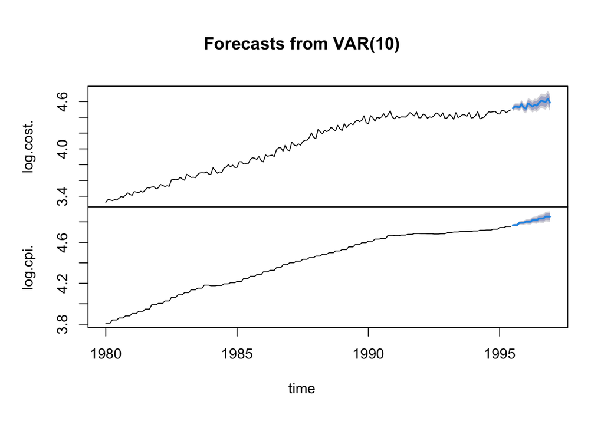

```r
plot(var_pred)
```

3. Plot the residuals’ ACF. Discuss your results.

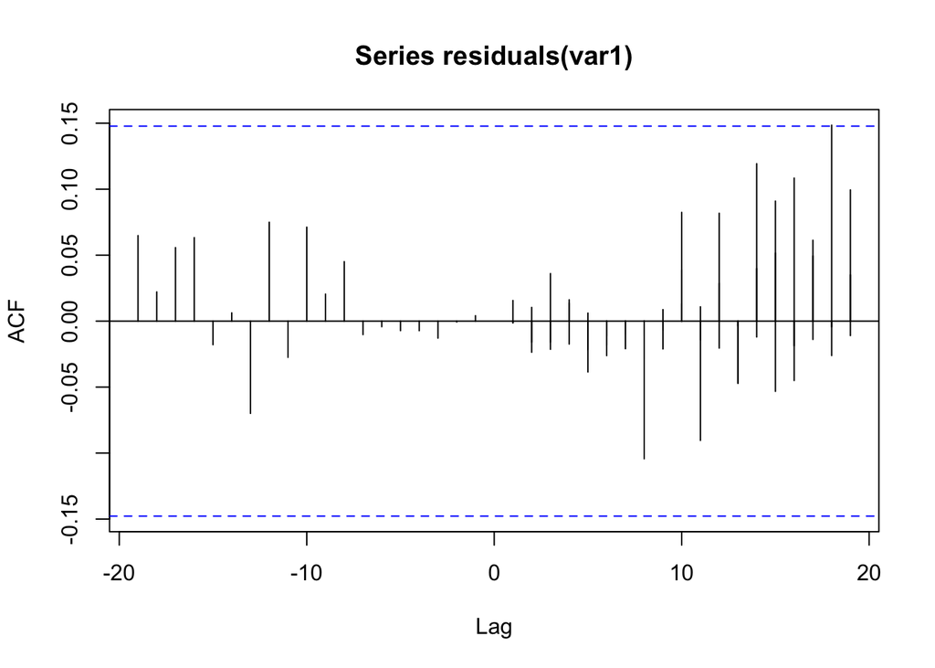

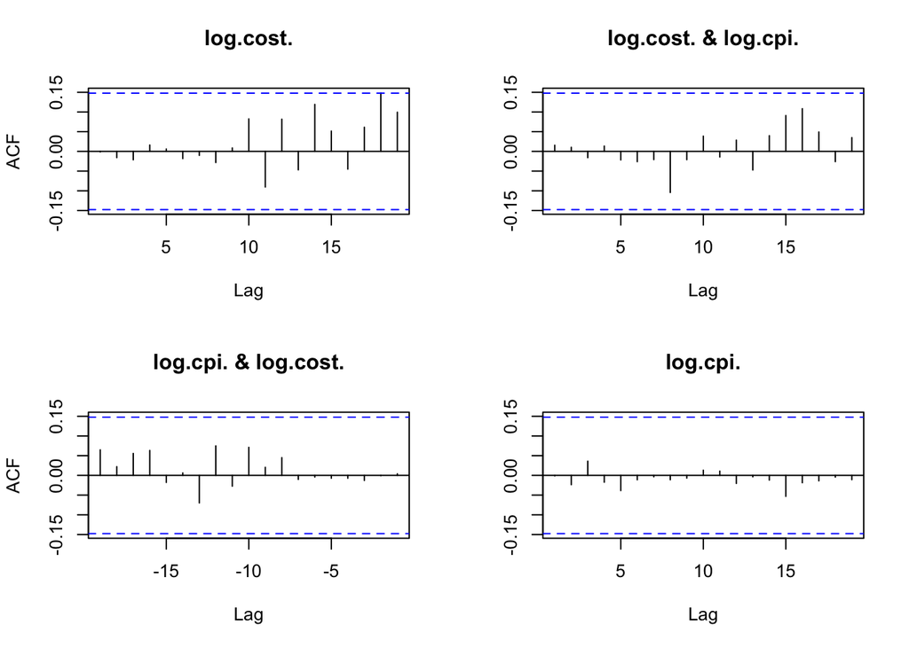

```r
plot(acf(residuals(var1)))
```

From the acf plot, we could see that there are no seasonality and trend for the residuals of VAR(10) model, and no lag is significant for the residual of VAR(10). The residuals also look like white noise for other acf plots, therefore, this means that the model capture the pattern in the data very well.